# MGT 4050 Project Demo: Spotify Data Analysis Case Study

Zhaohu(Jonathan) Fan

10/01/2025

## Introduction

*Introduction*

This study examines **Spotify’s** music library to understand how popularity relates to genres, release timing, and audio features. By mapping simple patterns in the catalog, we aim to draw insights that inform product and catalog strategy.

This report addresses the following questions:

- How have Spotify listeners’ interests changed over time (by release year and genre mix)?
  - What is the distribution of genres across Spotify’s library (and among top tracks)?
  - Does a song’s popularity correlate with audio features such as loudness, danceability, and acousticness?
  - How are these features distributed across the library, and do they differ for more- vs. less-popular songs?

## Packages Required

We use the following R packages:

| Library | Description |
| --- | --- |
| *‘ggplot2’* | a R package dedicated to data visualizations. |
| *‘dplyr’* | a R package dedicated to data wrangling. |
| *‘tidyverse’* | a R package dedicated to data wrangling and data manipulation. |
| *‘knitr’* | a R package dedicated to an engine for dynamic report generation. |

## Data Preparation

### Data Source

We use the Spotify songs dataset from TidyTuesday [GitHub](https://github.com/rfordatascience/tidytuesday/blob/master/data/2020/2020-01-21/readme.md) . The repository provides cleaned track-level metadata and audio features suitable for exploratory analysis and teaching reproducibility.

### Data Import

The dataset contains **32,833** tracks and **23** variables spanning the **late 1950s–2019**.

**Metadata** - `track_name`, `artist_name`, `album_name`, `release_year`, `track_id`, `track_popularity`

**Audio features** - `danceability`, `energy`, `loudness`, `speechiness`, `acousticness`, `instrumentalness`, `liveness`, `valence`, `tempo`, and others

### Preview of Raw Data

The table below shows the first five rows of the imported dataset.

```r
spotify_data <- readr::read_csv('https://raw.githubusercontent.com/rfordatascience/tidytuesday/master/data/2020/2020-01-21/spotify_songs.csv')

kable(head(spotify_data,5))
```

| track_id | track_name | track_artist | track_popularity | track_album_id | track_album_name | track_album_release_date | playlist_name | playlist_id | playlist_genre | playlist_subgenre | danceability | energy | key | loudness | mode | speechiness | acousticness | instrumentalness | liveness | valence | tempo | duration_ms |
| --- | --- | --- | --- | --- | --- | --- | --- | --- | --- | --- | --- | --- | --- | --- | --- | --- | --- | --- | --- | --- | --- | --- |
| 6f807x0ima9a1j3VPbc7VN | I Don’t Care (with Justin Bieber) - Loud Luxury Remix | Ed Sheeran | 66 | 2oCs0DGTsRO98Gh5ZSl2Cx | I Don’t Care (with Justin Bieber) [Loud Luxury Remix] | 2019-06-14 | Pop Remix | 37i9dQZF1DXcZDD7cfEKhW | pop | dance pop | 0.748 | 0.916 | 6 | -2.634 | 1 | 0.0583 | 0.1020 | 0.00e+00 | 0.0653 | 0.518 | 122.036 | 194754 |
| 0r7CVbZTWZgbTCYdfa2P31 | Memories - Dillon Francis Remix | Maroon 5 | 67 | 63rPSO264uRjW1X5E6cWv6 | Memories (Dillon Francis Remix) | 2019-12-13 | Pop Remix | 37i9dQZF1DXcZDD7cfEKhW | pop | dance pop | 0.726 | 0.815 | 11 | -4.969 | 1 | 0.0373 | 0.0724 | 4.21e-03 | 0.3570 | 0.693 | 99.972 | 162600 |
| 1z1Hg7Vb0AhHDiEmnDE79l | All the Time - Don Diablo Remix | Zara Larsson | 70 | 1HoSmj2eLcsrR0vE9gThr4 | All the Time (Don Diablo Remix) | 2019-07-05 | Pop Remix | 37i9dQZF1DXcZDD7cfEKhW | pop | dance pop | 0.675 | 0.931 | 1 | -3.432 | 0 | 0.0742 | 0.0794 | 2.33e-05 | 0.1100 | 0.613 | 124.008 | 176616 |
| 75FpbthrwQmzHlBJLuGdC7 | Call You Mine - Keanu Silva Remix | The Chainsmokers | 60 | 1nqYsOef1yKKuGOVchbsk6 | Call You Mine - The Remixes | 2019-07-19 | Pop Remix | 37i9dQZF1DXcZDD7cfEKhW | pop | dance pop | 0.718 | 0.930 | 7 | -3.778 | 1 | 0.1020 | 0.0287 | 9.40e-06 | 0.2040 | 0.277 | 121.956 | 169093 |
| 1e8PAfcKUYoKkxPhrHqw4x | Someone You Loved - Future Humans Remix | Lewis Capaldi | 69 | 7m7vv9wlQ4i0LFuJiE2zsQ | Someone You Loved (Future Humans Remix) | 2019-03-05 | Pop Remix | 37i9dQZF1DXcZDD7cfEKhW | pop | dance pop | 0.650 | 0.833 | 1 | -4.672 | 1 | 0.0359 | 0.0803 | 0.00e+00 | 0.0833 | 0.725 | 123.976 | 189052 |

**Data Structure**

Spotify data includes 32833 tracks and 23 attributes.

```r
print(paste('The data has',dim(spotify_data)[1],'rows and',dim(spotify_data)[2],'attributes'))
```

```
## [1] "The data has 32833 rows and 23 attributes"
```

### Data Dictionary

We observe 10 character variables and 13 numeric variables. A brief description of the Spotify dataset follows.

```r
spotify_data_dictionary <- readr::read_csv('https://raw.githubusercontent.com/rfordatascience/tidytuesday/master/data/2020/2020-01-21/spotify_songs.csv')
datatable(spotify_data_dictionary, options = list(
  autoWidth = TRUE,
  columnDefs = list(list(className = 'dt-center', targets = 3)),
  pageLength = 25,
  lengthMenu = c(5, 10, 15, 20, 25)
))
```

|  | track_id | track_name | track_artist | track_popularity | track_album_id | track_album_name | track_album_release_date | playlist_name | playlist_id | playlist_genre | playlist_subgenre | danceability | energy | key | loudness | mode | speechiness | acousticness | instrumentalness | liveness | valence | tempo | duration_ms |
| --- | --- | --- | --- | --- | --- | --- | --- | --- | --- | --- | --- | --- | --- | --- | --- | --- | --- | --- | --- | --- | --- | --- | --- |
| 1 | 6f807x0ima9a1j3VPbc7VN | I Don't Care (with Justin Bieber) - Loud Luxury Remix | Ed Sheeran | 66 | 2oCs0DGTsRO98Gh5ZSl2Cx | I Don't Care (with Justin Bieber) [Loud Luxury Remix] | 2019-06-14 | Pop Remix | 37i9dQZF1DXcZDD7cfEKhW | pop | dance pop | 0.748 | 0.916 | 6 | -2.634 | 1 | 0.0583 | 0.102 | 0 | 0.0653 | 0.518 | 122.036 | 194754 |
| 2 | 0r7CVbZTWZgbTCYdfa2P31 | Memories - Dillon Francis Remix | Maroon 5 | 67 | 63rPSO264uRjW1X5E6cWv6 | Memories (Dillon Francis Remix) | 2019-12-13 | Pop Remix | 37i9dQZF1DXcZDD7cfEKhW | pop | dance pop | 0.726 | 0.815 | 11 | -4.969 | 1 | 0.0373 | 0.0724 | 0.00421 | 0.357 | 0.693 | 99.972 | 162600 |
| 3 | 1z1Hg7Vb0AhHDiEmnDE79l | All the Time - Don Diablo Remix | Zara Larsson | 70 | 1HoSmj2eLcsrR0vE9gThr4 | All the Time (Don Diablo Remix) | 2019-07-05 | Pop Remix | 37i9dQZF1DXcZDD7cfEKhW | pop | dance pop | 0.675 | 0.931 | 1 | -3.432 | 0 | 0.0742 | 0.0794 | 2.33e-05 | 0.11 | 0.613 | 124.008 | 176616 |
| 4 | 75FpbthrwQmzHlBJLuGdC7 | Call You Mine - Keanu Silva Remix | The Chainsmokers | 60 | 1nqYsOef1yKKuGOVchbsk6 | Call You Mine - The Remixes | 2019-07-19 | Pop Remix | 37i9dQZF1DXcZDD7cfEKhW | pop | dance pop | 0.718 | 0.93 | 7 | -3.778 | 1 | 0.102 | 0.0287 | 9.43e-06 | 0.204 | 0.277 | 121.956 | 169093 |
| 5 | 1e8PAfcKUYoKkxPhrHqw4x | Someone You Loved - Future Humans Remix | Lewis Capaldi | 69 | 7m7vv9wlQ4i0LFuJiE2zsQ | Someone You Loved (Future Humans Remix) | 2019-03-05 | Pop Remix | 37i9dQZF1DXcZDD7cfEKhW | pop | dance pop | 0.65 | 0.833 | 1 | -4.672 | 1 | 0.0359 | 0.0803 | 0 | 0.0833 | 0.725 | 123.976 | 189052 |
| 6 | 7fvUMiyapMsRRxr07cU8Ef | Beautiful People (feat. Khalid) - Jack Wins Remix | Ed Sheeran | 67 | 2yiy9cd2QktrNvWC2EUi0k | Beautiful People (feat. Khalid) [Jack Wins Remix] | 2019-07-11 | Pop Remix | 37i9dQZF1DXcZDD7cfEKhW | pop | dance pop | 0.675 | 0.919 | 8 | -5.385 | 1 | 0.127 | 0.0799 | 0 | 0.143 | 0.585 | 124.982 | 163049 |
| 7 | 2OAylPUDDfwRGfe0lYqlCQ | Never Really Over - R3HAB Remix | Katy Perry | 62 | 7INHYSeusaFlyrHSNxm8qH | Never Really Over (R3HAB Remix) | 2019-07-26 | Pop Remix | 37i9dQZF1DXcZDD7cfEKhW | pop | dance pop | 0.449 | 0.856 | 5 | -4.788 | 0 | 0.0623 | 0.187 | 0 | 0.176 | 0.152 | 112.648 | 187675 |
| 8 | 6b1RNvAcJjQH73eZO4BLAB | Post Malone (feat. RANI) - GATTÜSO Remix | Sam Feldt | 69 | 6703SRPsLkS4bPtMFFJes1 | Post Malone (feat. RANI) [GATTÜSO Remix] | 2019-08-29 | Pop Remix | 37i9dQZF1DXcZDD7cfEKhW | pop | dance pop | 0.542 | 0.903 | 4 | -2.419 | 0 | 0.0434 | 0.0335 | 4.83e-06 | 0.111 | 0.367 | 127.936 | 207619 |
| 9 | 7bF6tCO3gFb8INrEDcjNT5 | Tough Love - Tiësto Remix / Radio Edit | Avicii | 68 | 7CvAfGvq4RlIwEbT9o8Iav | Tough Love (Tiësto Remix) | 2019-06-14 | Pop Remix | 37i9dQZF1DXcZDD7cfEKhW | pop | dance pop | 0.594 | 0.935 | 8 | -3.562 | 1 | 0.0565 | 0.0249 | 3.97e-06 | 0.637 | 0.366 | 127.015 | 193187 |
| 10 | 1IXGILkPm0tOCNeq00kCPa | If I Can't Have You - Gryffin Remix | Shawn Mendes | 67 | 4QxzbfSsVryEQwvPFEV5Iu | If I Can't Have You (Gryffin Remix) | 2019-06-20 | Pop Remix | 37i9dQZF1DXcZDD7cfEKhW | pop | dance pop | 0.642 | 0.818 | 2 | -4.552 | 1 | 0.032 | 0.0567 | 0 | 0.0919 | 0.59 | 124.957 | 253040 |

[output cut: 32823 more lines]

### Summary Statistics

```r
summary(spotify_data[,c(4,12:23)])
```

```
##  track_popularity  danceability        energy              key
##  Min.   :  0.00   Min.   :0.0000   Min.   :0.000175   Min.   : 0.000
##  1st Qu.: 24.00   1st Qu.:0.5630   1st Qu.:0.581000   1st Qu.: 2.000
##  Median : 45.00   Median :0.6720   Median :0.721000   Median : 6.000
##  Mean   : 42.48   Mean   :0.6548   Mean   :0.698619   Mean   : 5.374
##  3rd Qu.: 62.00   3rd Qu.:0.7610   3rd Qu.:0.840000   3rd Qu.: 9.000
##  Max.   :100.00   Max.   :0.9830   Max.   :1.000000   Max.   :11.000
##     loudness            mode         speechiness      acousticness
##  Min.   :-46.448   Min.   :0.0000   Min.   :0.0000   Min.   :0.0000
##  1st Qu.: -8.171   1st Qu.:0.0000   1st Qu.:0.0410   1st Qu.:0.0151
##  Median : -6.166   Median :1.0000   Median :0.0625   Median :0.0804
##  Mean   : -6.720   Mean   :0.5657   Mean   :0.1071   Mean   :0.1753
##  3rd Qu.: -4.645   3rd Qu.:1.0000   3rd Qu.:0.1320   3rd Qu.:0.2550
##  Max.   :  1.275   Max.   :1.0000   Max.   :0.9180   Max.   :0.9940
##  instrumentalness       liveness         valence           tempo
##  Min.   :0.0000000   Min.   :0.0000   Min.   :0.0000   Min.   :  0.00
##  1st Qu.:0.0000000   1st Qu.:0.0927   1st Qu.:0.3310   1st Qu.: 99.96
##  Median :0.0000161   Median :0.1270   Median :0.5120   Median :121.98
##  Mean   :0.0847472   Mean   :0.1902   Mean   :0.5106   Mean   :120.88
##  3rd Qu.:0.0048300   3rd Qu.:0.2480   3rd Qu.:0.6930   3rd Qu.:133.92
##  Max.   :0.9940000   Max.   :0.9960   Max.   :0.9910   Max.   :239.44
##   duration_ms
##  Min.   :  4000
##  1st Qu.:187819
##  Median :216000
##  Mean   :225800
##  3rd Qu.:253585
##  Max.   :517810
```

### Data Preprocessing

#### Inspect columns and basic structure

```r
glimpse(spotify_data)
```

```
## Rows: 32,833
## Columns: 23
## $ track_id                 <chr> "6f807x0ima9a1j3VPbc7VN", "0r7CVbZTWZgbTCYdfa…
## $ track_name               <chr> "I Don't Care (with Justin Bieber) - Loud Lux…
## $ track_artist             <chr> "Ed Sheeran", "Maroon 5", "Zara Larsson", "Th…
## $ track_popularity         <dbl> 66, 67, 70, 60, 69, 67, 62, 69, 68, 67, 58, 6…
## $ track_album_id           <chr> "2oCs0DGTsRO98Gh5ZSl2Cx", "63rPSO264uRjW1X5E6…
## $ track_album_name         <chr> "I Don't Care (with Justin Bieber) [Loud Luxu…
## $ track_album_release_date <chr> "2019-06-14", "2019-12-13", "2019-07-05", "20…
## $ playlist_name            <chr> "Pop Remix", "Pop Remix", "Pop Remix", "Pop R…
## $ playlist_id              <chr> "37i9dQZF1DXcZDD7cfEKhW", "37i9dQZF1DXcZDD7cf…
## $ playlist_genre           <chr> "pop", "pop", "pop", "pop", "pop", "pop", "po…
## $ playlist_subgenre        <chr> "dance pop", "dance pop", "dance pop", "dance…
## $ danceability             <dbl> 0.748, 0.726, 0.675, 0.718, 0.650, 0.675, 0.4…
## $ energy                   <dbl> 0.916, 0.815, 0.931, 0.930, 0.833, 0.919, 0.8…
## $ key                      <dbl> 6, 11, 1, 7, 1, 8, 5, 4, 8, 2, 6, 8, 1, 5, 5,…
## $ loudness                 <dbl> -2.634, -4.969, -3.432, -3.778, -4.672, -5.38…
## $ mode                     <dbl> 1, 1, 0, 1, 1, 1, 0, 0, 1, 1, 1, 1, 1, 0, 0, …
## $ speechiness              <dbl> 0.0583, 0.0373, 0.0742, 0.1020, 0.0359, 0.127…
## $ acousticness             <dbl> 0.10200, 0.07240, 0.07940, 0.02870, 0.08030, …
## $ instrumentalness         <dbl> 0.00e+00, 4.21e-03, 2.33e-05, 9.43e-06, 0.00e…
## $ liveness                 <dbl> 0.0653, 0.3570, 0.1100, 0.2040, 0.0833, 0.143…
## $ valence                  <dbl> 0.518, 0.693, 0.613, 0.277, 0.725, 0.585, 0.1…
## $ tempo                    <dbl> 122.036, 99.972, 124.008, 121.956, 123.976, 1…
## $ duration_ms              <dbl> 194754, 162600, 176616, 169093, 189052, 16304…
```

#### Checking Missing Values

We examine missingness per column to decide whether to **drop**, **retain**, or **impute** (e.g., mean/median for numeric fields).

```r
colSums(is.na(spotify_data))
```

```
##                 track_id               track_name             track_artist
##                        0                        5                        5
##         track_popularity           track_album_id         track_album_name
##                        0                        0                        5
## track_album_release_date            playlist_name              playlist_id
##                        0                        0                        0
##           playlist_genre        playlist_subgenre             danceability
##                        0                        0                        0
##                   energy                      key                 loudness
##                        0                        0                        0
##                     mode              speechiness             acousticness
##                        0                        0                        0
##         instrumentalness                 liveness                  valence
##                        0                        0                        0
##                    tempo              duration_ms
##                        0                        0
```

```r
spotify_data %>%
  filter_all(any_vars(is.na(.)))
```

```
## # A tibble: 5 × 23
##   track_id               track_name track_artist track_popularity track_album_id
##   <chr>                  <chr>      <chr>                   <dbl> <chr>
## 1 69gRFGOWY9OMpFJgFol1u0 <NA>       <NA>                        0 717UG2du6utFe…
## 2 5cjecvX0CmC9gK0Laf5EMQ <NA>       <NA>                        0 3luHJEPw434tv…
## 3 5TTzhRSWQS4Yu8xTgAuq6D <NA>       <NA>                        0 3luHJEPw434tv…
## 4 3VKFip3OdAvv4OfNTgFWeQ <NA>       <NA>                        0 717UG2du6utFe…
## 5 69gRFGOWY9OMpFJgFol1u0 <NA>       <NA>                        0 717UG2du6utFe…
## # ℹ 18 more variables: track_album_name <chr>, track_album_release_date <chr>,
## #   playlist_name <chr>, playlist_id <chr>, playlist_genre <chr>,
## #   playlist_subgenre <chr>, danceability <dbl>, energy <dbl>, key <dbl>,
## #   loudness <dbl>, mode <dbl>, speechiness <dbl>, acousticness <dbl>,
## #   instrumentalness <dbl>, liveness <dbl>, valence <dbl>, tempo <dbl>,
## #   duration_ms <dbl>
```

We observe missing values in three identifier fields—**track_name**, **track_album_name**, and **track_artist**—totaling **< 0.1%** of rows. Given the minimal impact and the importance of these fields for analysis, we remove those rows.

```r
spotify_data <- spotify_data %>% drop_na()
```

#### Identifying Duplicate Values

According to the data dictionary, **`track_id`** uniquely identifies each song. We checked for duplicates in this column and removed them to ensure one record per track.

```r
spotify_data %>% distinct(track_id, .keep_all=TRUE) %>% dim()
```

```
## [1] 28352    23
```

```r
spotify_data <- spotify_data %>% distinct(track_id,.keep_all=TRUE)
```

#### Creating New Variable(s)

```r
spotify_data <- spotify_data %>% mutate(duration_m = duration_ms/60000)
spotify_data <- select(spotify_data, -duration_ms)
colnames(spotify_data)
```

```
##  [1] "track_id"                 "track_name"
##  [3] "track_artist"             "track_popularity"
##  [5] "track_album_id"           "track_album_name"
##  [7] "track_album_release_date" "playlist_name"
##  [9] "playlist_id"              "playlist_genre"
## [11] "playlist_subgenre"        "danceability"
## [13] "energy"                   "key"
## [15] "loudness"                 "mode"
## [17] "speechiness"              "acousticness"
## [19] "instrumentalness"         "liveness"
## [21] "valence"                  "tempo"
## [23] "duration_m"
```

#### Deriving Release Year for Trend Analysis

Track popularity appears to vary by **time** and **genre**, so we will analyze popularity trends **by year**. To do this, we extract the year from `track_album_release_date` and create `track_album_release_year`. This provides a clear, interpretable time scale for exploratory analysis.

```r
spotify_data$track_album_release_date <- as.Date(spotify_data$track_album_release_date)
spotify_data$track_album_release_year <- as.numeric(format(spotify_data$track_album_release_date, "%Y"))
```

```r
track_popularity_uniques <- spotify_data %>% distinct(track_popularity) %>% select(track_popularity)
tags <- c("[0-20]","(20-40]", "(40-60]", "(60-80]", "(80-100]", "(100+]")

spotify_data_binned <- spotify_data %>%
  mutate(track_popularity_tag = case_when(
    track_popularity <= 20 ~ tags[1],
    track_popularity > 20 & track_popularity <= 40 ~ tags[2],
    track_popularity > 40 & track_popularity <= 60 ~ tags[3],
    track_popularity > 60 & track_popularity <= 80 ~ tags[4],
    track_popularity > 80 & track_popularity <= 100 ~ tags[5],
    track_popularity > 100 ~ tags[6]
    ))
spotify_data_binned %>% distinct(track_popularity_tag)
```

```
## # A tibble: 5 × 1
##   track_popularity_tag
##   <chr>
## 1 (60-80]
## 2 (40-60]
## 3 (20-40]
## 4 [0-20]
## 5 (80-100]
```

#### Checking Outlier(s)

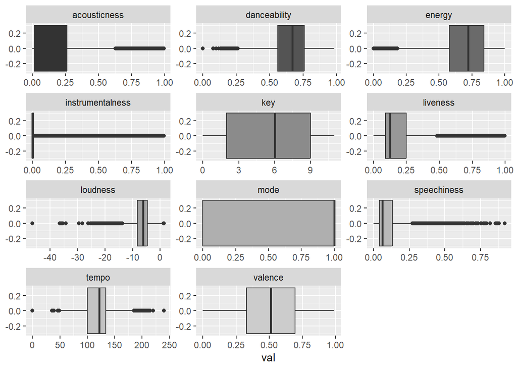

```r
spotify_pivot <- spotify_data_binned %>% select(12:22) %>% pivot_longer(cols = danceability:tempo, names_to =
"Var", values_to = "val")
ggplot(spotify_pivot, aes(y = val, fill  = Var))+
  geom_boxplot(show.legend = FALSE, width = .6, position = "dodge")+
  coord_flip() +
  facet_wrap(vars(Var), ncol=3, scales = "free") + scale_fill_grey()
```

In the absence of specific domain guidance, we will **retain** the apparent outliers for now. Extreme values may reflect genuine phenomena (e.g., unusually long tracks or atypical audio profiles) that could help explain popularity patterns. We will document this choice and revisit it in sensitivity checks during modeling.

#### Histograms

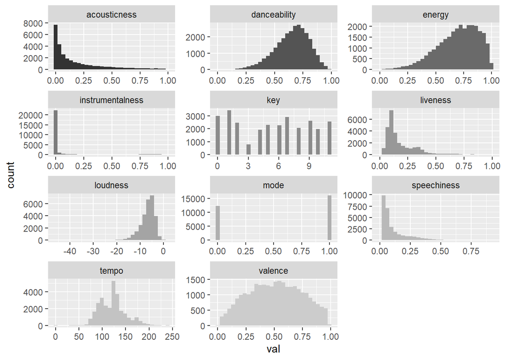

```r
ggplot(spotify_pivot, aes(x = val, fill  = Var))+
  geom_histogram(show.legend = FALSE,  position = "dodge") +
  facet_wrap(vars(Var), ncol=3, scales = "free") + scale_fill_grey()
```

### Data Preview

Here’s a quick look at the cleaned data.

The following is the final preview of the cleaned data.

```r
spotify_data_cleaned <- spotify_data_binned
datatable(head(spotify_data_cleaned, 25), options = list(
  scrollCollapse = TRUE,scrollX = TRUE,
  autoWidth = TRUE,
  columnDefs = list(list(className = 'dt-center', targets = 5)),
  pageLength = 5,
  lengthMenu = c(5, 10, 15, 20, 25)
))
```

|  | track_id | track_name | track_artist | track_popularity | track_album_id | track_album_name | track_album_release_date | playlist_name | playlist_id | playlist_genre | playlist_subgenre | danceability | energy | key | loudness | mode | speechiness | acousticness | instrumentalness | liveness | valence | tempo | duration_m | track_album_release_year | track_popularity_tag |
| --- | --- | --- | --- | --- | --- | --- | --- | --- | --- | --- | --- | --- | --- | --- | --- | --- | --- | --- | --- | --- | --- | --- | --- | --- | --- |
| 1 | 6f807x0ima9a1j3VPbc7VN | I Don't Care (with Justin Bieber) - Loud Luxury Remix | Ed Sheeran | 66 | 2oCs0DGTsRO98Gh5ZSl2Cx | I Don't Care (with Justin Bieber) [Loud Luxury Remix] | 2019-06-14 | Pop Remix | 37i9dQZF1DXcZDD7cfEKhW | pop | dance pop | 0.748 | 0.916 | 6 | -2.634 | 1 | 0.0583 | 0.102 | 0 | 0.0653 | 0.518 | 122.036 | 3.2459 | 2019 | (60-80] |
| 2 | 0r7CVbZTWZgbTCYdfa2P31 | Memories - Dillon Francis Remix | Maroon 5 | 67 | 63rPSO264uRjW1X5E6cWv6 | Memories (Dillon Francis Remix) | 2019-12-13 | Pop Remix | 37i9dQZF1DXcZDD7cfEKhW | pop | dance pop | 0.726 | 0.815 | 11 | -4.969 | 1 | 0.0373 | 0.0724 | 0.00421 | 0.357 | 0.693 | 99.972 | 2.71 | 2019 | (60-80] |
| 3 | 1z1Hg7Vb0AhHDiEmnDE79l | All the Time - Don Diablo Remix | Zara Larsson | 70 | 1HoSmj2eLcsrR0vE9gThr4 | All the Time (Don Diablo Remix) | 2019-07-05 | Pop Remix | 37i9dQZF1DXcZDD7cfEKhW | pop | dance pop | 0.675 | 0.931 | 1 | -3.432 | 0 | 0.0742 | 0.0794 | 2.33e-05 | 0.11 | 0.613 | 124.008 | 2.9436 | 2019 | (60-80] |
| 4 | 75FpbthrwQmzHlBJLuGdC7 | Call You Mine - Keanu Silva Remix | The Chainsmokers | 60 | 1nqYsOef1yKKuGOVchbsk6 | Call You Mine - The Remixes | 2019-07-19 | Pop Remix | 37i9dQZF1DXcZDD7cfEKhW | pop | dance pop | 0.718 | 0.93 | 7 | -3.778 | 1 | 0.102 | 0.0287 | 9.43e-06 | 0.204 | 0.277 | 121.956 | 2.818216666666667 | 2019 | (40-60] |
| 5 | 1e8PAfcKUYoKkxPhrHqw4x | Someone You Loved - Future Humans Remix | Lewis Capaldi | 69 | 7m7vv9wlQ4i0LFuJiE2zsQ | Someone You Loved (Future Humans Remix) | 2019-03-05 | Pop Remix | 37i9dQZF1DXcZDD7cfEKhW | pop | dance pop | 0.65 | 0.833 | 1 | -4.672 | 1 | 0.0359 | 0.0803 | 0 | 0.0833 | 0.725 | 123.976 | 3.150866666666666 | 2019 | (60-80] |
| 6 | 7fvUMiyapMsRRxr07cU8Ef | Beautiful People (feat. Khalid) - Jack Wins Remix | Ed Sheeran | 67 | 2yiy9cd2QktrNvWC2EUi0k | Beautiful People (feat. Khalid) [Jack Wins Remix] | 2019-07-11 | Pop Remix | 37i9dQZF1DXcZDD7cfEKhW | pop | dance pop | 0.675 | 0.919 | 8 | -5.385 | 1 | 0.127 | 0.0799 | 0 | 0.143 | 0.585 | 124.982 | 2.717483333333333 | 2019 | (60-80] |
| 7 | 2OAylPUDDfwRGfe0lYqlCQ | Never Really Over - R3HAB Remix | Katy Perry | 62 | 7INHYSeusaFlyrHSNxm8qH | Never Really Over (R3HAB Remix) | 2019-07-26 | Pop Remix | 37i9dQZF1DXcZDD7cfEKhW | pop | dance pop | 0.449 | 0.856 | 5 | -4.788 | 0 | 0.0623 | 0.187 | 0 | 0.176 | 0.152 | 112.648 | 3.127916666666667 | 2019 | (60-80] |
| 8 | 6b1RNvAcJjQH73eZO4BLAB | Post Malone (feat. RANI) - GATTÜSO Remix | Sam Feldt | 69 | 6703SRPsLkS4bPtMFFJes1 | Post Malone (feat. RANI) [GATTÜSO Remix] | 2019-08-29 | Pop Remix | 37i9dQZF1DXcZDD7cfEKhW | pop | dance pop | 0.542 | 0.903 | 4 | -2.419 | 0 | 0.0434 | 0.0335 | 4.83e-06 | 0.111 | 0.367 | 127.936 | 3.460316666666666 | 2019 | (60-80] |
| 9 | 7bF6tCO3gFb8INrEDcjNT5 | Tough Love - Tiësto Remix / Radio Edit | Avicii | 68 | 7CvAfGvq4RlIwEbT9o8Iav | Tough Love (Tiësto Remix) | 2019-06-14 | Pop Remix | 37i9dQZF1DXcZDD7cfEKhW | pop | dance pop | 0.594 | 0.935 | 8 | -3.562 | 1 | 0.0565 | 0.0249 | 3.97e-06 | 0.637 | 0.366 | 127.015 | 3.219783333333333 | 2019 | (60-80] |
| 10 | 1IXGILkPm0tOCNeq00kCPa | If I Can't Have You - Gryffin Remix | Shawn Mendes | 67 | 4QxzbfSsVryEQwvPFEV5Iu | If I Can't Have You (Gryffin Remix) | 2019-06-20 | Pop Remix | 37i9dQZF1DXcZDD7cfEKhW | pop | dance pop | 0.642 | 0.818 | 2 | -4.552 | 1 | 0.032 | 0.0567 | 0 | 0.0919 | 0.59 | 124.957 | 4.217333333333333 | 2019 | (60-80] |

[output cut: 15 more lines]

## Proposed Exploratory Data Analysis

As a first step, we describe user listening patterns and track characteristics, then fit simple statistical models (e.g., correlations and regressions) to answer the business questions and generate insights.

### Correlation Analysis

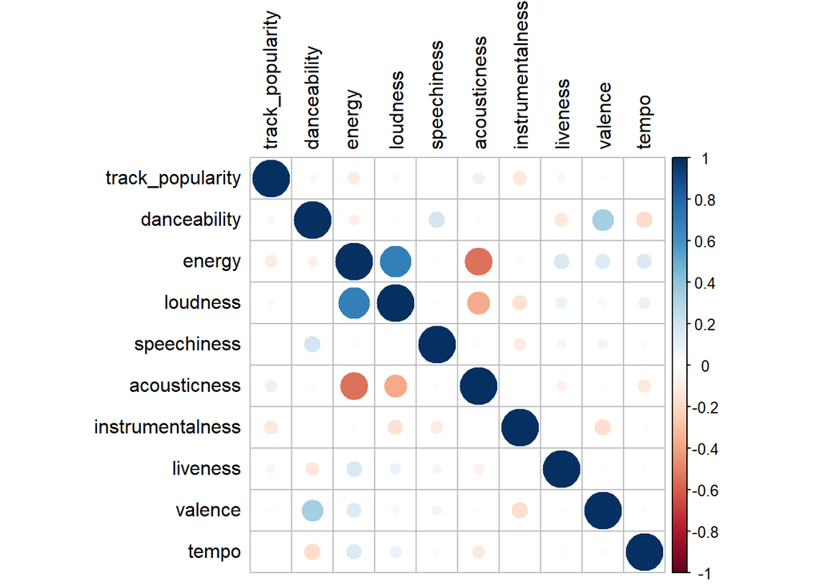

```r
corr_data <-select(spotify_data_cleaned,track_popularity, danceability, energy, loudness, speechiness, acousticness, instrumentalness, liveness, valence, tempo)
corrplot(cor(corr_data), tl.col = 'black')
```

- **Observations**
  - **Energy and loudness** exhibit a strong positive correlation.
  - **Popularity** shows only weak associations with the audio features overall; no single feature is strongly correlated with popularity.
  - **Energy vs. acousticness** is negatively correlated, and **loudness vs. acousticness** is also negatively correlated.

We plot yearly counts of released tracks by **genre** to understand catalog trends.

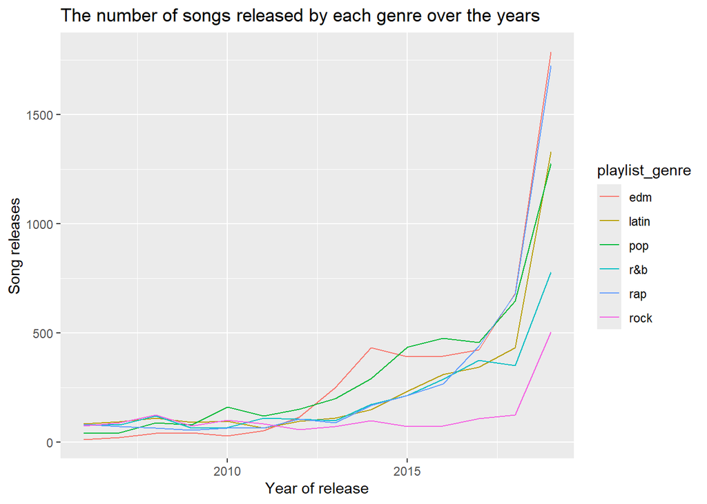

```r
song_years_genre_df <- spotify_data_cleaned %>%
  filter(track_album_release_year> 2005 & track_album_release_year<=2019)%>%
  select('track_album_release_year', 'playlist_genre')  %>%
  group_by(track_album_release_year, playlist_genre) %>%
  summarise(songs_released = n()) %>%
  ungroup()
ggplot(song_years_genre_df, aes(x = track_album_release_year, y = songs_released)) +
  geom_line(aes(color = playlist_genre)) +
    ggtitle("The number of songs released by each genre over the years") +
      ylab("Song releases") +xlab("Year of release")
```

### Recap

We conducted an initial examination of listening patterns and catalog dynamics. Next, we will extend the exploratory analysis and estimate statistical models (e.g., correlation and regression) to address the business questions and derive evidence-based insights.